# sdmShiny Project

### Land cover

For this one, let’s also look at some statistics

```r
Land_Cover_stats <- raster::ratify(myIVs$Land_Cover, count = T)
ratlc               <- raster::levels(Land_Cover_stats)[[1]]
ratlc$Land_Cover <- c("Built-up",
                                    "Agricultural",
                                    "Forest",
                                    "Open-natural vegetation",
                                    "Mires",
                                    "Glaciers/Ice/Snow",
                                    "Freshwater",
                                    "Sea",
                                    "NA")
ratlc
```

```
##   ID  COUNT              Land_Cover
## 1 10   1435                Built-up
## 2 20   9482            Agricultural
## 3 30 138689                  Forest
## 4 50 144319 Open-natural vegetation
## 5 60  10278                   Mires
## 6 70   2443       Glaciers/Ice/Snow
## 7 81  11452              Freshwater
## 8 82  12467                     Sea
## 9 99   3237                      NA
```

Norway is mostly open natural vegetation and forest. There’s very little buildt up areas and glaciers. For the sake of modeling plant distributions we can group all the obviously unsuitable areas like water, glaciers, and also ‘Built-up’ I think (red-liste plants are not found on parking lots that often). This should simplify the models considerably. I’ll keep the NA as they are, but put the others in a clas == 98 wich I’ll call ‘other’.

```r
myIVs$Land_Cover[myIVs$Land_Cover == 10 |
                   myIVs$Land_Cover == 70 |
                   myIVs$Land_Cover == 81 |
                   myIVs$Land_Cover == 82] <- 98
myIVs$Land_Cover <- raster::ratify(myIVs$Land_Cover)
ratlc               <- raster::levels(myIVs$Land_Cover)[[1]]
ratlc$Land_Cover <- c(
                                    "Agricultural",
                                    "Forest",
                                    "Open-natural vegetation",
                                    "Mires",


                                    "others",
                                    "NA")
ratlc
```

```
##   ID              Land_Cover
## 1 20            Agricultural
## 2 30                  Forest
## 3 50 Open-natural vegetation
## 4 60                   Mires
## 5 98                  others
## 6 99                      NA
```

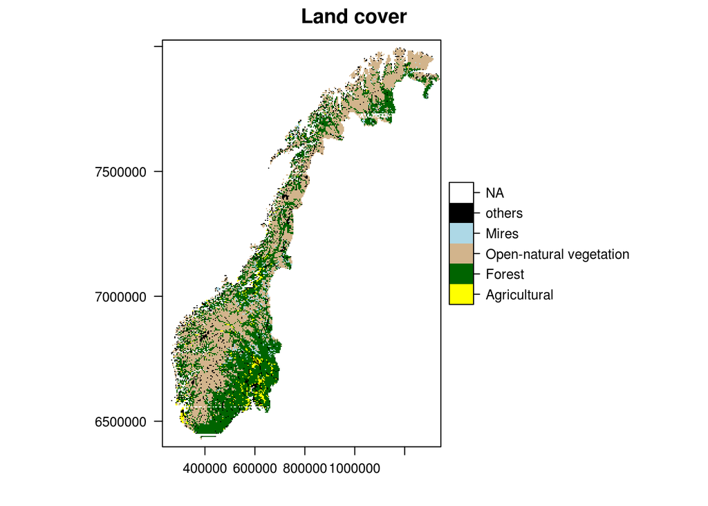

```r
levels(myIVs$Land_Cover) <- ratlc
cols <- colorRampPalette(c(
                           "yellow",
                           "darkgreen",
                           "tan",
                           "lightblue",
                           "black",
                           "white"
                           ))
rasterVis::levelplot(myIVs$Land_Cover, main = "Land cover", col.regions = cols)
```

### Forest type

```r
raster::levels(raster::ratify(myIVs$Forest_Type))
```

```
## [[1]]
##   ID
## 1 31
## 2 32
## 3 33
## 4 39
## 5 98
## 6 99
```

Deleting class 98 and 99 as above, but also 39 although I’, not sure what that is…

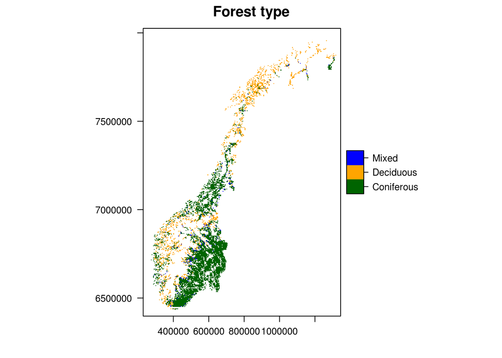

```r
myIVs$Forest_Type[myIVs$Forest_Type>33]<-NA
myIVs$Forest_Type<-raster::ratify(myIVs$Forest_Type)
ratlct<-raster::levels(myIVs$Forest_Type)[[1]]
ratlct[['ForestType']] <-
  c('Coniferous','Deciduous','Mixed')
levels(myIVs$Forest_Type) <- ratlct
cols3 <- colorRampPalette(c("darkgreen", "orange", "blue" ))
rasterVis::levelplot(myIVs$Forest_Type, main= "Forest type", col.regions = cols3)
```